# DATA 606 Data Project Proposal

simplymathematics

# Project Proposal

I intend to investigate the link between policing and race by examinging the distribution of arrests by race and comparing that to the population by race.

$H_0:$ The NYPD does not target certain racial groups for enforcement more than others.

$H_A:$ The NYPD does target certain racial groups for enforcement nore than others.

### Data Preparation

```r
stops <- read.csv("sqf-2017.csv")
with(stops, table(stops$race, stops$year));
```

```
##
##     2016
##        0
##   A  737
##   B 6498
##   I   38
##   P  873
##   Q 2753
##   U   95
##   W 1270
##   Z  140
```

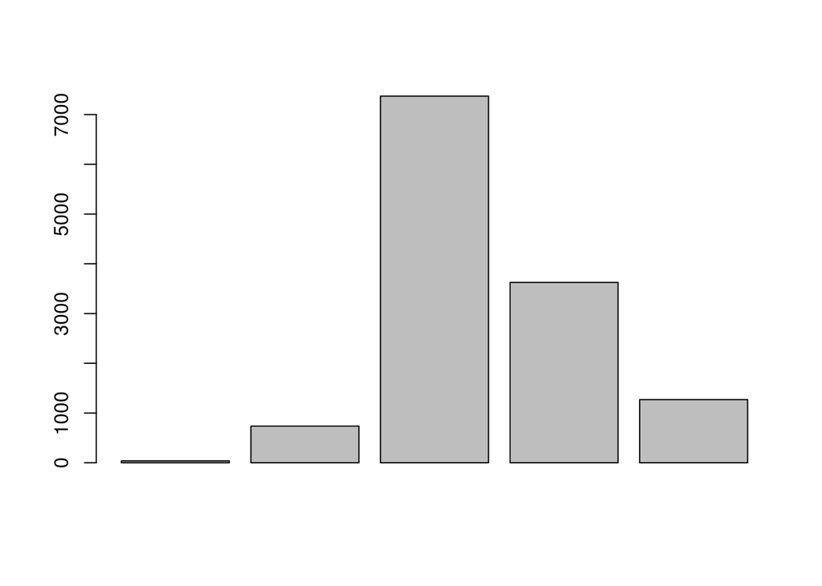

```r
stop.amer.ind <- 38
stop.asian.pacific <-737
stop.white <- 1270
stop.hispanic <- 873 + 2753
stop.black <-6498+873
stops <- c(stop.amer.ind, stop.asian.pacific, stop.black, stop.hispanic, stop.white)


stop.total <- sum(stops)

total <- (57512 + 3597341 + 2158851 + 1038388 + 5147 + 2088510 + 177225) #This is different than population total because census data treats 'Hispanic' separately than race, leading to double counting of ~2 million people. This is fine for my purposes however as the census data still accurately reports who identifies as 'black'  and 'white' or 'Hispanic' and people are free to choose multiple options. Because of the discrepancies in racial bookeeping in the agencies, each hispanic person will be double counted as either white or black from the information provided by the NYPD. This ensures that a person's bi-racial status does not affect their race or the independence between sets.


exp.amer.ind <- 57512
exp.white <- 3597341
exp.asian.pacific <- (1038388+5147)
exp.black <- 2088510
exp.hispanic <-(2158851+177225)



measured <- c(stop.amer.ind, stop.asian.pacific, stop.black, stop.hispanic, stop.white)
expected <- c(exp.amer.ind, exp.asian.pacific, exp.black, exp.hispanic, exp.white)/total*stop.total
expected.total <- sum(expected)

barplot(measured)
```

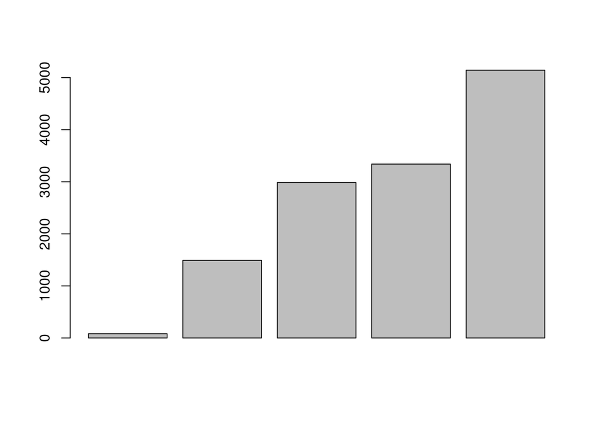

```r
barplot(expected)
```

```r
top <- (measured-expected)^2
sum(top/expected)
```

```
## [1] 9787.617
```

```r
pchisq(900, df = 4, lower.tail=FALSE)
```

```
## [1] 1.665941e-193
```

# Research Question

From the self-reported NYPD data, is there evidence of racialized policing?

# Observations

```
shuf -n 60000 NYPD_Arrests_Data__Historic_.csv > arrest_sample.csv
```

# Data Collection

# Type of Study

This is an observational study.

# Response Variable

Number of Stops/ Race # Explanatory Variable Race

# Relevant Statistics

```r
chi.sq.statistic <- sum(((measured-expected)^2)/expected)
pchisq(chi.sq.statistic, df = 4, lower.tail=FALSE)
```

```
## [1] 0
```

```r
chi <- chisq.test(as.table(rbind(measured,expected)), simulate.p.value = FALSE)
chi
```

```
##
##  Pearson's Chi-squared test
##
## data:  as.table(rbind(measured, expected))
## X-squared = 4479.3, df = 4, p-value < 2.2e-16
```

Because $P(x) < \alpha$, we can reject the null hypothesis.

# Inference

- Our observations are a simple random sample of all arrests.
- The total sample size >30, <10% population size
- Each cell should have more than 5 values.
- We assume the racial composition of one arrestee does not influence the racial composition of the next person who is arrested.

# Source:

[Chi-Square Test](http://mathworld.wolfram.com/Chi-SquaredTest.html)

Source for expected values:[2010 Census:](https://factfinder.census.gov/faces/tableservices/jsf/pages/productview.xhtml?src=CF) Source for measured values: [NYC Open Data](https://data.cityofnewyork.us/Public-Safety/The-Stop-Question-and-Frisk-Data/ftxv-d5ix/data)